# Final_exam_html

Seoyun Yang

## 1. A map of mobility

#### a. Make a plot where the x and y coordinates are longitude and latitude, and mobility is indicated by color (possibly grey scale), by a third coordinate, or some other suitable device. Make sure your map is legible. Describe the geographic pattern in words. [logitude, latitude, mobility]

*그래프를 보아 미국 대륙 중부의 Mobility(경제적 이동성)이 높으며, 서부와 동부 쪽으로 갈수록 Mobility가 상대적으로 낮아지는 경향을 보인다.*

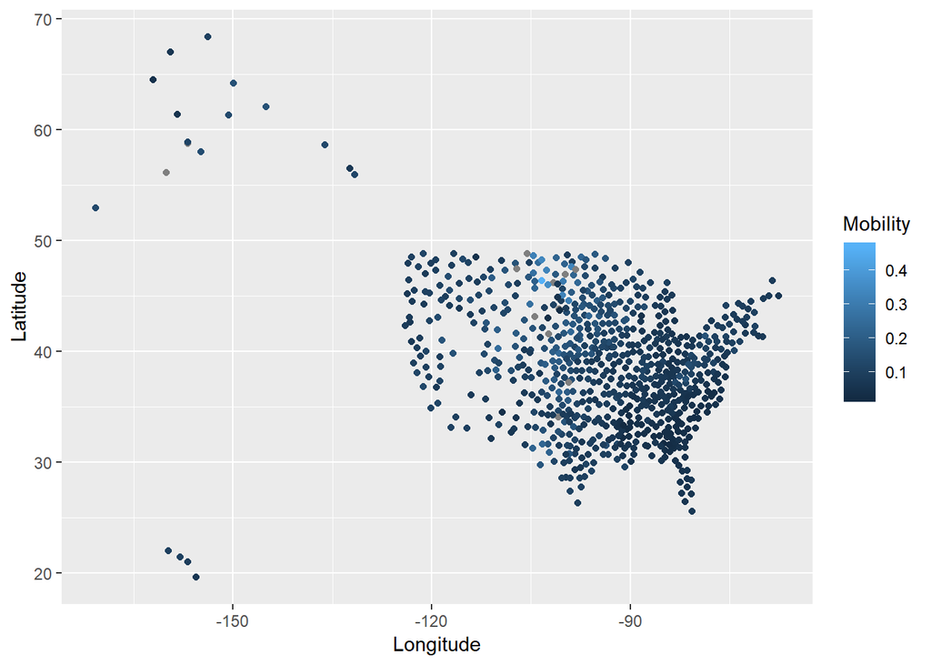

```r
scatter.1a <- ggplot(data=dat, aes(x=Longitude, y=Latitude, col=Mobility)) + geom_point()
scatter.1a
```

#### b. Discretizing the Mobility values may enhance visualizing. Create a new variable, called MobilityCat with values high if Mobility > 0.1, and low otherwise. Make a plot where the x and y coordinates are longitude and latitude, and the categorized mobility (i.e. MobilityCat) is indicated by color. This time, filter your observations so that only the continental part of USA is visible (that is, remove data corresponding to Alaska and Hawaii). Has the geographic pattern become clearer?

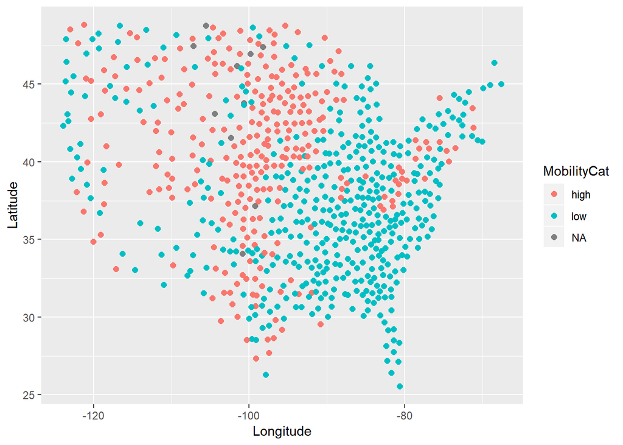

```r
dat$MobilityCat[Mobility>0.1]="high"
dat$MobilityCat[Mobility<=0.1]="low"
dat.1b <- dat[-c(which(State=='AK'|State=='HI')),]
scatter.1b <- ggplot(data=dat.1b, aes(x=Longitude, y=Latitude,
                                      col=MobilityCat)) + geom_point(size=2)
scatter.1b
```

## 2. A bunch of simple regression models

Make scatter plots of mobility against each of the following variables. Include on each plot a line for the simple or univariate regression, and give a table of the regression coefficients. Carefully explain the interpretation of each coefficient. Do any of the results seem odd?

#### a. Population

*Population의 단위가 크기 때문에 log를 써서 scaling 했다. 적합 결과 회귀 계수 추정치가 -0.0165636로, Mobility와 Population은 음의 상관관계를 보인다. 또한 해당하는 p-value가 매우 낮아 계수는 유의하다고 할 수 있다. 그래프를 보면 전반적으로 선형 관계를 보이나 값이 15를 넘어가면 살짝 양의 상관관계를 보이는 특징이 있다.*

```
##
##
## Table: Coefficients
##
##                  Estimate   Std. Error     t value   Pr(>|t|)
## ------------  -----------  -----------  ----------  ---------
## (Intercept)     0.2925080    0.0126972    23.03715          0
## variable       -0.0165636    0.0010851   -15.26522          0
```

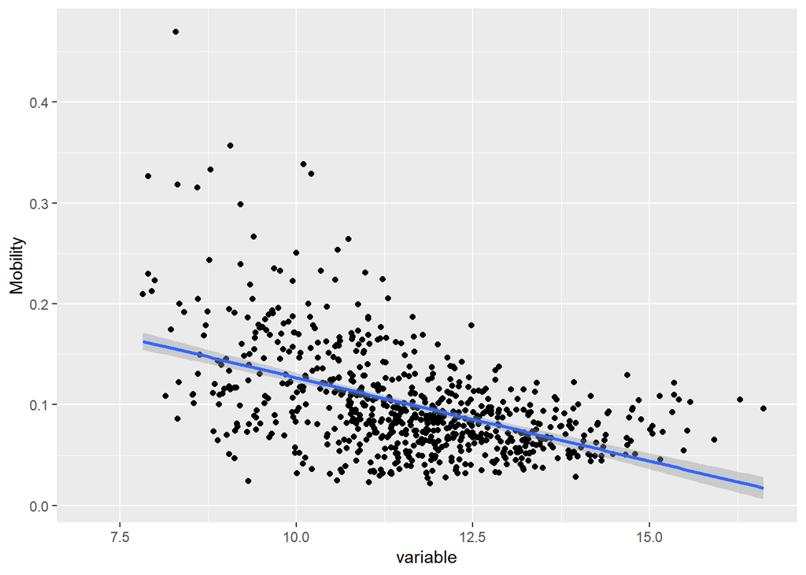

```r
# make a function
simple.reg<-function(variable){
  lm.fit<-lm(Mobility~variable)
  print(knitr::kable(summary(lm.fit)$coef, caption='Coefficients'))
  ggplot(dat, mapping=aes(variable, Mobility)) + geom_point() + geom_smooth(method='lm')
}
simple.reg(log(Population))
```

#### b. Mean household income per capita

*적합 결과 회귀 계수 추정치에 대한 p-vlaue가 0.362로 통계적으로 유의하지 않은 편이다. 그래프로 봐서도 Income과 Mobility 사이에 뚜렷한 선형 관계가 보이지 않는다. 두 변수를 선형 회귀 모델로 설명하기 어렵다고 할 수 있다.*

```r
simple.reg(Income)
```

```
##
##
## Table: Coefficients
##
##                 Estimate   Std. Error     t value    Pr(>|t|)
## ------------  ----------  -----------  ----------  ----------
## (Intercept)    0.0902463    0.0113347   7.9619628   0.0000000
## variable       0.0000003    0.0000003   0.9114705   0.3623496
```

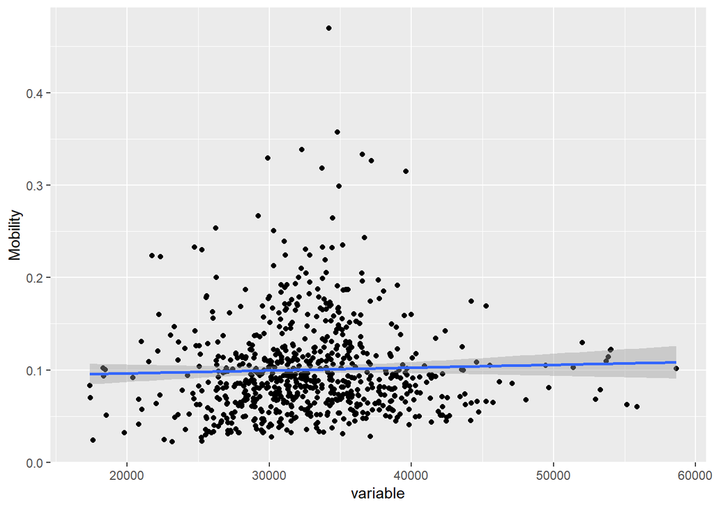

#### c. Racial segregation

*회귀 계수 추정치는 -0.1835019로, 음의 상관관계를 가진다. 회귀 계수에 대한 p-value는 매우 작은 값이므로, 통계적으로 유의하다.*

```r
simple.reg(Seg_racial)
```

```
##
##
## Table: Coefficients
##
##                  Estimate   Std. Error     t value   Pr(>|t|)
## ------------  -----------  -----------  ----------  ---------
## (Intercept)     0.1246090    0.0030375   41.023043          0
## variable       -0.1835019    0.0183933   -9.976578          0
```

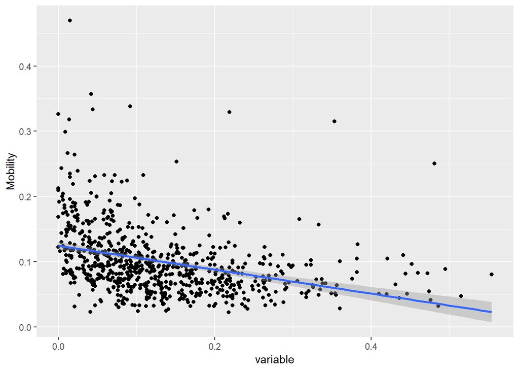

#### d. Income share of the top 1%

```r
simple.reg(Share01)
```

```
##
##
## Table: Coefficients
##
##                  Estimate   Std. Error     t value   Pr(>|t|)
## ------------  -----------  -----------  ----------  ---------
## (Intercept)     0.1162509    0.0042074   27.630306    0.0e+00
## variable       -0.0017182    0.0003518   -4.883502    1.3e-06
```

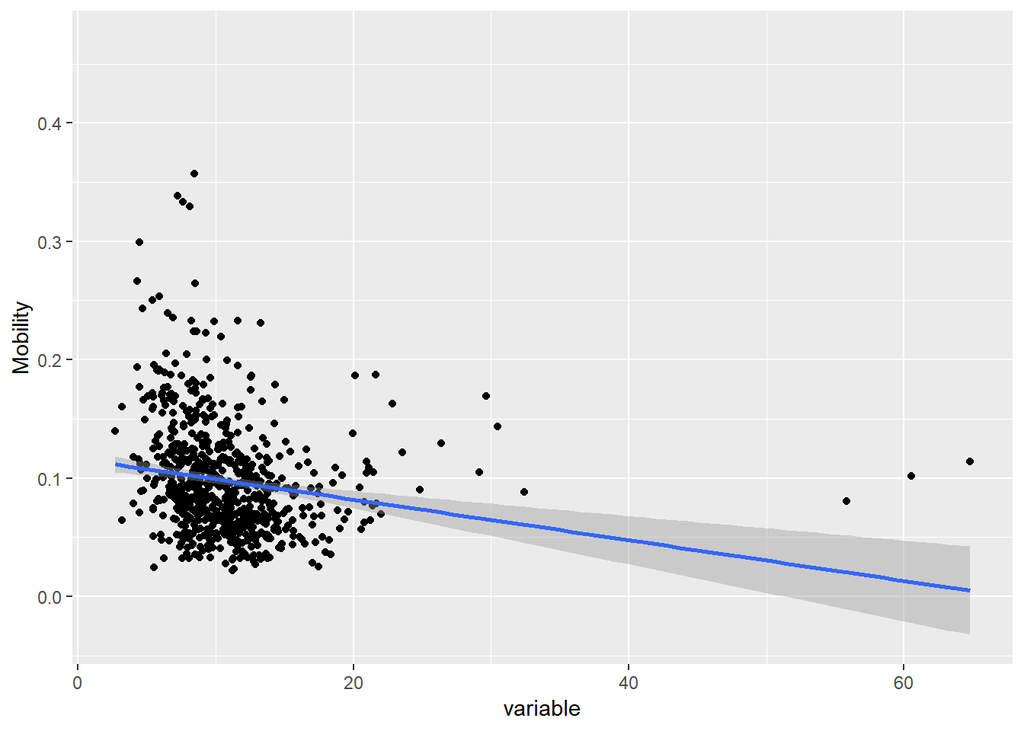

#### e. Mean school expenditures per pupil

*두 변수 사이의 회귀 계수는 0.0114643로, 양의 상관관계를 가진다. 회귀 계수에 대한 p-value는 매우 작은 값이므로, 통계적으로 유의하다.*

```r
simple.reg(School_spending)
```

```
##
##
## Table: Coefficients
##
##                 Estimate   Std. Error    t value    Pr(>|t|)
## ------------  ----------  -----------  ---------  ----------
## (Intercept)    0.0316789    0.0101701   3.114901   0.0019133
## variable       0.0114643    0.0016623   6.896569   0.0000000
```

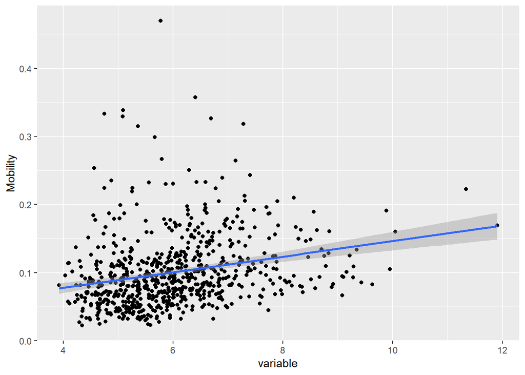

#### f. Violent crime rate

*두 변수 사이의 회귀 계수는 -10.0505704로, 음의 상관관계를 가진다. 회귀 계수에 대한 p-value는 매우 작은 값이므로, 통계적으로 유의하다. 다만 Violent_crime는 categorical 특성을 가지고 있고 소수의 이상점이 눈에 띈다.*

```r
simple.reg(Violent_crime)
```

```
##
##
## Table: Coefficients
##
##                   Estimate   Std. Error     t value   Pr(>|t|)
## ------------  ------------  -----------  ----------  ---------
## (Intercept)      0.1176149    0.0028343   41.496660          0
## variable       -10.0505704    1.2943766   -7.764796          0
```

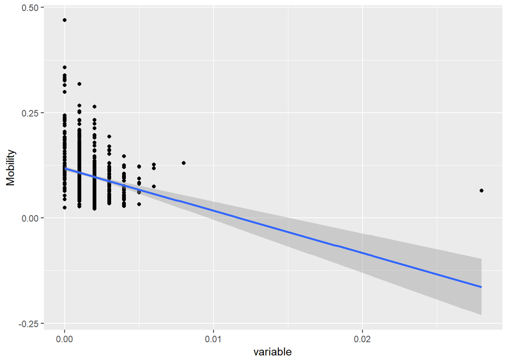

#### g. Fraction of workers with short commutes

*두 변수 사이의 회귀 계수는 0.2218695로, 양의 상관관계를 가진다. 회귀 계수에 대한 p-value는 매우 작은 값이므로, 통계적으로 유의하다.*

```r
simple.reg(Commute)
```

```
##
##
## Table: Coefficients
##
##                  Estimate   Std. Error      t value    Pr(>|t|)
## ------------  -----------  -----------  -----------  ----------
## (Intercept)    -0.0001973    0.0053362   -0.0369665   0.9705219
## variable        0.2218695    0.0112422   19.7353372   0.0000000
```

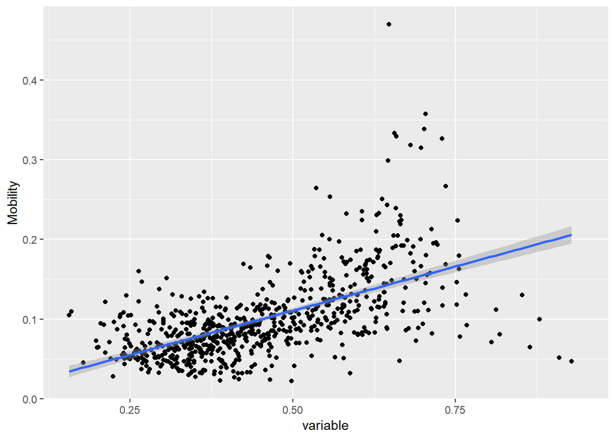

## 3. All things considered

Run a linear regression of mobility against all appropriate covariates.

#### a. Report all regression coefficients and their standard errors; you may use either a table or a figure as you prefer.

```r
# 최소한의 변수 2개 제외(ID, Name)
dat.3a <- raw[-c(1,2,4)]
dat.3a$MobilityCat[Mobility>0.1]="high"
dat.3a$MobilityCat[Mobility<=0.1]="low"
lm.fit.3a <- lm(Mobility~., data=dat.3a)
summary(lm.fit.3a)
```

```
##
## Call:
## lm(formula = Mobility ~ ., data = dat.3a)
##
## Residuals:
##       Min        1Q    Median        3Q       Max
## -0.065479 -0.009800 -0.001565  0.009166  0.129853
##
## Coefficients:
##                             Estimate Std. Error t value Pr(>|t|)
## (Intercept)                1.237e-01  6.602e-02   1.874  0.06176 .
## Population                 2.042e-10  1.983e-09   0.103  0.91805
## Urban                      6.983e-04  3.202e-03   0.218  0.82747
## Black                      5.364e-02  2.346e-02   2.287  0.02278 *
## Seg_racial                -2.256e-02  1.534e-02  -1.470  0.14234
## Seg_income                 8.514e-01  7.573e-01   1.124  0.26162
## Seg_poverty               -6.738e-01  4.076e-01  -1.653  0.09913 .
## Seg_affluence             -2.689e-01  3.791e-01  -0.709  0.47855
## Commute                    5.938e-02  2.330e-02   2.548  0.01121 *
## Income                     6.685e-07  5.464e-07   1.223  0.22192
## Gini                       2.826e+00  2.630e+00   1.075  0.28314
## Share01                   -2.831e-02  2.630e-02  -1.076  0.28258
## Gini_99                   -2.900e+00  2.630e+00  -1.103  0.27082
## Middle_class               5.255e-02  3.902e-02   1.347  0.17883
## Local_tax_rate             3.030e-02  2.169e-01   0.140  0.88899
## Local_gov_spending        -9.717e-07  2.524e-06  -0.385  0.70044
## Progressivity              4.993e-03  1.021e-03   4.888 1.51e-06 ***
## EITC                      -6.351e-04  3.726e-04  -1.704  0.08914 .
## School_spending           -1.489e-03  1.882e-03  -0.791  0.42937
## Student_teacher_ratio     -1.584e-04  9.307e-04  -0.170  0.86494
## Test_scores                5.840e-04  2.515e-04   2.322  0.02077 *
## HS_dropout                -1.883e-01  6.992e-02  -2.694  0.00738 **
## Colleges                  -5.583e-02  6.597e-02  -0.846  0.39789
## Tuition                   -1.037e-07  3.645e-07  -0.284  0.77628
## Graduation                -4.792e-03  1.156e-02  -0.415  0.67862
## Labor_force_participation -4.971e-02  4.336e-02  -1.146  0.25237
## Manufacturing             -1.351e-01  2.341e-02  -5.773 1.63e-08 ***
## Chinese_imports           -3.903e-04  6.382e-04  -0.612  0.54123
## Teenage_labor             -2.201e+00  1.755e+00  -1.254  0.21065
## Migration_in              -7.933e-02  2.516e-01  -0.315  0.75273
## Migration_out             -3.708e-01  3.082e-01  -1.203  0.22976
## Foreign_born               9.912e-02  4.538e-02   2.184  0.02956 *
## Social_capital            -3.587e-03  2.220e-03  -1.616  0.10699
## Religious                  5.366e-02  1.057e-02   5.078 6.01e-07 ***
## Violent_crime             -2.747e+00  1.350e+00  -2.035  0.04251 *
## Single_mothers            -2.238e-01  7.711e-02  -2.902  0.00392 **
## Divorced                   1.489e-01  1.293e-01   1.152  0.25014
## Married                   -5.423e-02  6.119e-02  -0.886  0.37606
## Longitude                  8.995e-05  1.866e-04   0.482  0.62997
## Latitude                   1.566e-03  4.839e-04   3.235  0.00132 **
## MobilityCatlow            -2.805e-02  3.158e-03  -8.884  < 2e-16 ***
## ---
## Signif. codes:  0 '***' 0.001 '**' 0.01 '*' 0.05 '.' 0.1 ' ' 1
##
## Residual standard error: 0.02039 on 377 degrees of freedom
##   (323 observations deleted due to missingness)
## Multiple R-squared:  0.8065, Adjusted R-squared:  0.7859
## F-statistic: 39.28 on 40 and 377 DF,  p-value: < 2.2e-16
```

```r
coef.3a <- summary(lm.fit.3a)$coef[,1]
knitr::kable(summary(lm.fit.3a)$coef[,1], caption="coefficients")
```

coefficients

|  | x |
| --- | --- |
| (Intercept) | 0.1236872 |
| Population | 0.0000000 |
| Urban | 0.0006983 |
| Black | 0.0536371 |
| Seg_racial | -0.0225553 |
| Seg_income | 0.8514175 |
| Seg_poverty | -0.6738206 |
| Seg_affluence | -0.2689395 |
| Commute | 0.0593849 |
| Income | 0.0000007 |
| Gini | 2.8263514 |
| Share01 | -0.0283059 |
| Gini_99 | -2.9001109 |
| Middle_class | 0.0525528 |
| Local_tax_rate | 0.0302983 |
| Local_gov_spending | -0.0000010 |
| Progressivity | 0.0049926 |
| EITC | -0.0006351 |
| School_spending | -0.0014887 |
| Student_teacher_ratio | -0.0001584 |
| Test_scores | 0.0005840 |
| HS_dropout | -0.1883438 |
| Colleges | -0.0558327 |
| Tuition | -0.0000001 |
| Graduation | -0.0047920 |
| Labor_force_participation | -0.0497095 |
| Manufacturing | -0.1351179 |
| Chinese_imports | -0.0003903 |
| Teenage_labor | -2.2007912 |
| Migration_in | -0.0793270 |
| Migration_out | -0.3707613 |
| Foreign_born | 0.0991196 |
| Social_capital | -0.0035869 |
| Religious | 0.0536581 |
| Violent_crime | -2.7469051 |
| Single_mothers | -0.2238020 |
| Divorced | 0.1488919 |
| Married | -0.0542263 |
| Longitude | 0.0000899 |
| Latitude | 0.0015656 |
| MobilityCatlow | -0.0280535 |

```r
knitr::kable(summary(lm.fit.3a)$coef[,2], caption="standard errors")
```

standard errors

|  | x |
| --- | --- |
| (Intercept) | 0.0660158 |
| Population | 0.0000000 |
| Urban | 0.0032019 |
| Black | 0.0234579 |
| Seg_racial | 0.0153418 |
| Seg_income | 0.7573176 |
| Seg_poverty | 0.4075951 |
| Seg_affluence | 0.3791364 |
| Commute | 0.0233020 |
| Income | 0.0000005 |
| Gini | 2.6295921 |
| Share01 | 0.0263046 |
| Gini_99 | 2.6297659 |
| Middle_class | 0.0390180 |
| Local_tax_rate | 0.2169200 |
| Local_gov_spending | 0.0000025 |
| Progressivity | 0.0010214 |
| EITC | 0.0003726 |
| School_spending | 0.0018817 |
| Student_teacher_ratio | 0.0009307 |
| Test_scores | 0.0002515 |
| HS_dropout | 0.0699185 |
| Colleges | 0.0659680 |
| Tuition | 0.0000004 |
| Graduation | 0.0115563 |
| Labor_force_participation | 0.0433624 |
| Manufacturing | 0.0234071 |
| Chinese_imports | 0.0006382 |
| Teenage_labor | 1.7551481 |
| Migration_in | 0.2516104 |
| Migration_out | 0.3082187 |
| Foreign_born | 0.0453784 |
| Social_capital | 0.0022200 |
| Religious | 0.0105672 |
| Violent_crime | 1.3495727 |
| Single_mothers | 0.0771080 |
| Divorced | 0.1292716 |
| Married | 0.0611876 |
| Longitude | 0.0001866 |
| Latitude | 0.0004839 |
| MobilityCatlow | 0.0031578 |

#### b. Explain why the ID variable must be excluded.

*ID는 커뮤니티 식별 코드로 형태는 숫자이나 그 값이 아무런 의미를 가지지 않는다. 회귀 모형에 설명 변수로 넣을 경우, ID의 값이 유의미해지므로 삭제해야 한다.*

#### c. Explain which other variables, if any, you excluded from the regression, and why. (If you think they can all be used, explain why.) [For this question, do not use any automated variable selection, and try to keep as many variables as possible.]

*Name 변수도 ID와 동일한 이유로 설명변수에서 제외되었다. Name 또한 ID와 마찬가지로 커뮤니티를 식별을 위해 들어가 있는 변수다. 커뮤니티의 이름은 커뮤니티의 경제적 이동성에 영향을 미칠 수 없다.*

#### d. Compare the coefficients you found in problem 2 to the coefficients for the same variables in this regression. Are they significantly different? Have any changed sign?

*단순 선형 회귀의 계수 추정치인 coef.2와 다중 회귀에서의 계수 추정치 coef.3d를 비교한 결과, 7개 변수에 대한 계수 추정치가 모두 달랐다. 그 중 부호가 바뀐 변수는 Population, School_spending이었다.*

```r
coef.2 <- c(-0.0165636, 0.0000003, -0.1835019, -0.0017182, 0.0114643, -10.0505704, 0.2218695)
coef.3d <- c(coef.3a[2], coef.3a[10], coef.3a[5], coef.3a[12], coef.3a[19], coef.3a[35], coef.3a[9])
total.coef.3d <- rbind(coef.2, coef.3d)
total.coef.3d
```

```
##           Population       Income  Seg_racial     Share01 School_spending
## coef.2  -1.65636e-02 3.000000e-07 -0.18350190 -0.00171820     0.011464300
## coef.3d  2.04176e-10 6.684998e-07 -0.02255533 -0.02830594    -0.001488684
##         Violent_crime   Commute
## coef.2     -10.050570 0.2218695
## coef.3d     -2.746905 0.0593849
```

#### e. Take a look at the variation inflation factor for each variable. Report those variables with VIF greater than 10. Do you suspect a (nearly) multicollinearity? If so, give a reason for, and suggest a way to avoid it.

```r
library("car")
vif.3e <- vif(lm.fit.3a)
data.frame(vif.3e)
```

```
##                                 vif.3e
## Population                    3.340487
## Urban                         2.570105
## Black                        10.832029
## Seg_racial                    2.213942
## Seg_income                  525.724979
## Seg_poverty                 130.486074
## Seg_affluence               161.762036
## Commute                       8.052646
## Income                        7.418282
## Gini                      41785.231918
## Share01                   11726.263380
## Gini_99                   22476.773703
## Middle_class                  9.253407
## Local_tax_rate                2.576614
## Local_gov_spending            2.262710
## Progressivity                 1.488264
## EITC                          2.235329
## School_spending               3.947006
## Student_teacher_ratio         2.696436
## Test_scores                   3.602617
## HS_dropout                    1.857347
## Colleges                      1.879166
## Tuition                       1.836465
## Graduation                    2.300098
## Labor_force_participation     5.962140
## Manufacturing                 2.838625
## Chinese_imports               1.372821
## Teenage_labor                 6.087682
## Migration_in                  5.423095
## Migration_out                 5.026330
## Foreign_born                  3.419292
## Social_capital                6.782504
## Religious                     2.308211
## Violent_crime                 1.808892
## Single_mothers               16.923788
## Divorced                      4.027636
## Married                       6.433995
## Longitude                     4.274848
## Latitude                      5.953014
## MobilityCat                   2.263205
```

```r
vif.3e[vif.3e>10]
```

```
##          Black     Seg_income    Seg_poverty  Seg_affluence           Gini
##       10.83203      525.72498      130.48607      161.76204    41785.23192
##        Share01        Gini_99 Single_mothers
##    11726.26338    22476.77370       16.92379
```

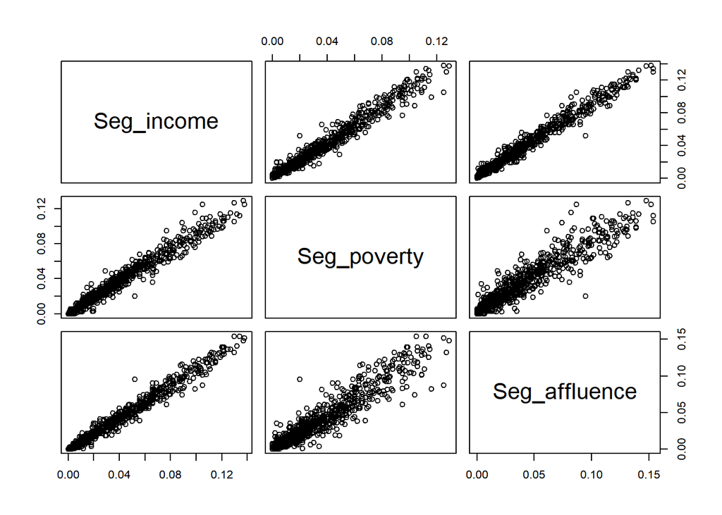

```r
seg.3e <- cbind(Seg_income, Seg_poverty, Seg_affluence)
pairs(seg.3e)
```

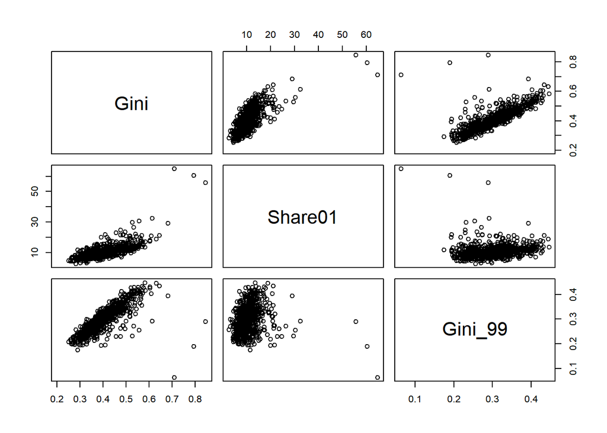

```r
gini.3e <- cbind(Gini, Share01, Gini_99)
pairs(gini.3e)
```

## 4. Please in my front yard

#### a. Inspect the missingness pattern in variables Colleges, Tuition and Graduation. [Note: NA is a missing value.] How many observations have no measurements for these variables?]

*Colleges, Tuition and Graduation 변수에서 총 478개의 결측치가 발견되었다.*

```r
cbind.4a <- cbind(Colleges, Tuition, Graduation)
sum(is.na(cbind.4a))
```

```
## [1] 478
```

#### b. Did the missing values happen at random? To answer this, plot a scatter of Mobility and Population (choose a suitable scale for Population), and inspect which data points have missing values in (all of, or some of) variables Colleges, Tuition and Graduation.

*x축을 log(Population), y축을 Mobility로 한 plot을 그리고 각각 Colleges, Tuition and Graduation 3개 변수의 데이터 포인트를 plot 위에 찍어보았다. 그 결과 세 변수의 NA값이 거의 동일하게 분포되어 있음을 확인했다. 즉 random으로 NA 값이 발생한 것이 아니라고 추측할 수 있다. Colleges, Tuition and Graduation은 각각 1인당 대학의 갯수, 등록금, 대학 졸업율을 의미하므로 해당 커뮤니티에 대학이 없을 시 세 변수 다 NA로 기록될 가능성이 높다.*

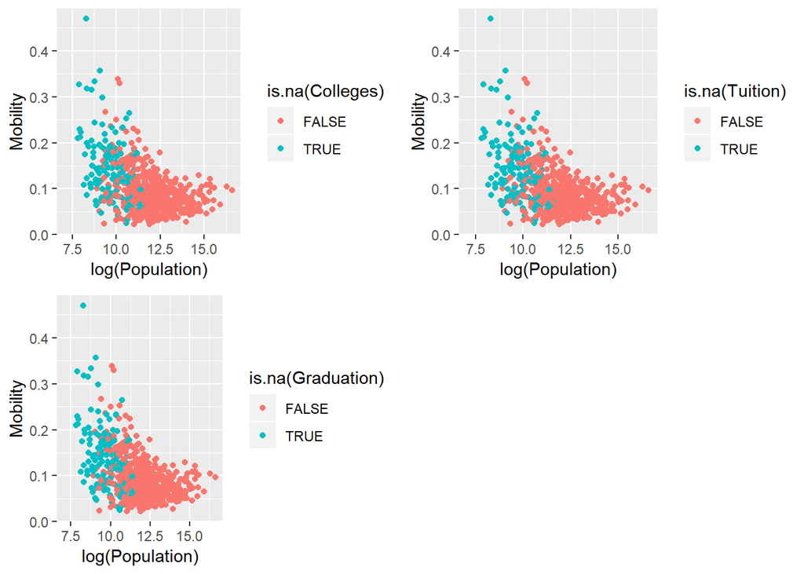

```r
cbind.4b <- cbind(Colleges, Tuition, Graduation, Population)
cbind.4b <- cbind.4b[order(Population),]
cbind.4b <- data.frame(cbind.4b)
library(gridExtra)
g1 <- ggplot(data=dat, aes(x=log(Population), y=Mobility, col=is.na(Colleges))) + geom_point()
g2 <- ggplot(data=dat, aes(x=log(Population), y=Mobility, col=is.na(Tuition))) + geom_point()
g3 <- ggplot(data=dat, aes(x=log(Population), y=Mobility, col=is.na(Graduation))) + geom_point()
grid.arrange(g1, g2, g3, nrow=2, ncol=2)
```

#### c. Create a new variable, called HE, whose value is TRUE if there is a higher education institution in the community, is FALSE if not. Replace all NA values in variables Colleges, Tuition and Graduation with 0.

```r
dat$Colleges[is.na(dat$Colleges)] <- 0
dat$Tuition[is.na(dat$Tuition)] <- 0
dat$Graduation[is.na(dat$Graduation)] <- 0
colleges.mean <- mean(dat$Colleges)
dat$HE[dat$Colleges>colleges.mean]=TRUE
dat$HE[dat$Colleges<=colleges.mean]=FALSE
```

## 5. All things considered, again.

#### Fit a linear regression model, incorporating your findings in problems 3 and 4. If you have removed, created, or modified variables, explain. Report all regression coefficients and their standard errors. Use this model for all problems below.

```r
final.dat.5 <- dat[,-c(1,2,4,10,11,15,16,20,21,44)]
# ID, Name, State
# estimate na -> Progressivity, EITC
simple.reg(Progressivity)
```

```
##
##
## Table: Coefficients
##
##                 Estimate   Std. Error     t value   Pr(>|t|)
## ------------  ----------  -----------  ----------  ---------
## (Intercept)    0.0951692    0.0021647   43.964951      0e+00
## variable       0.0068255    0.0013086    5.215814      2e-07
```

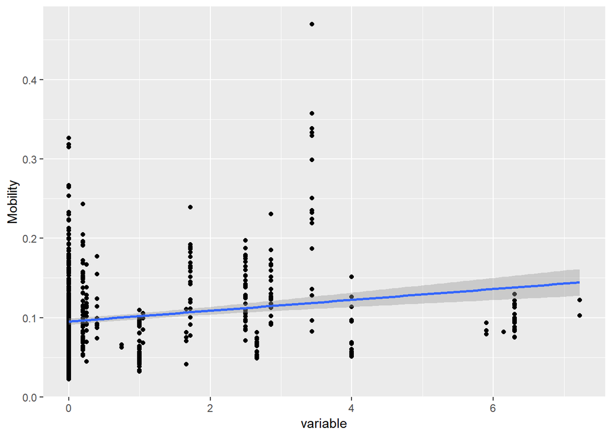

```r
simple.reg(EITC)
```

```
##
##
## Table: Coefficients
##
##                 Estimate   Std. Error     t value    Pr(>|t|)
## ------------  ----------  -----------  ----------  ----------
## (Intercept)    0.0982127    0.0020536   47.825001   0.0000000
## variable       0.0016335    0.0005030    3.247838   0.0012163
```

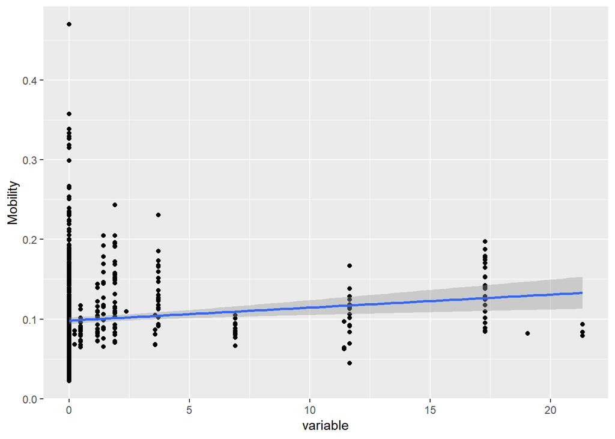

```r
# eliminate colinearity -> Seg_poverty, Seg_affluence, Share01, Gini_99
# eliminate duplicated variable -> HE
# names(final.dat.5)
# exclude missing value of y
final.dat.5 <- final.dat.5 %>% filter(!is.na(final.dat.5$Mobility))
# final linear regression model
lm.fit.final.5 <- lm(Mobility~., data=final.dat.5)
summary(lm.fit.final.5)$coef[,1] # coef
```

```
##               (Intercept)                Population
##              6.937220e-02             -5.177575e-10
##                     Urban                     Black
##             -1.409936e-03              5.329909e-02
##                Seg_racial                Seg_income
##             -6.723115e-02             -2.194397e-02
##                   Commute                    Income
##              3.167490e-02              8.456149e-07
##                      Gini              Middle_class
##             -6.049196e-03              1.731809e-01
##            Local_tax_rate        Local_gov_spending
##              6.201054e-01              1.025527e-06
##           School_spending     Student_teacher_ratio
##             -3.432339e-03             -1.657086e-04
##               Test_scores                HS_dropout
##             -2.661388e-04             -1.693170e-01
##                  Colleges                   Tuition
##              6.847913e-03              3.908849e-07
##                Graduation Labor_force_participation
##             -1.930190e-02             -6.412086e-02
##             Manufacturing           Chinese_imports
##             -1.715628e-01             -8.396775e-04
##             Teenage_labor              Migration_in
##             -3.555350e+00             -6.843577e-01
##             Migration_out              Foreign_born
##              9.290191e-02              4.687859e-02
##            Social_capital                 Religious
##             -4.212933e-03              5.302486e-02
##             Violent_crime            Single_mothers
##             -1.717042e+00             -3.367472e-01
##                  Divorced                   Married
##             -2.910644e-01             -3.661856e-02
##                 Longitude                  Latitude
##             -7.470744e-05              2.155797e-03
##                    HETRUE
##             -3.355993e-03
```

```r
summary(lm.fit.final.5)$coef[,2] # stderr
```

```
##               (Intercept)                Population
##              6.784410e-02              2.426629e-09
##                     Urban                     Black
##              4.028397e-03              2.698096e-02
##                Seg_racial                Seg_income
##              1.715460e-02              9.575399e-02
##                   Commute                    Income
##              2.606664e-02              5.775531e-07
##                      Gini              Middle_class
##              2.909713e-02              3.979004e-02
##            Local_tax_rate        Local_gov_spending
##              2.155838e-01              1.869355e-06
##           School_spending     Student_teacher_ratio
##              1.849413e-03              1.035704e-03
##               Test_scores                HS_dropout
##              2.673034e-04              8.123994e-02
##                  Colleges                   Tuition
##              8.148948e-02              4.429052e-07
##                Graduation Labor_force_participation
##              1.331280e-02              4.614546e-02
##             Manufacturing           Chinese_imports
##              2.532257e-02              7.910708e-04
##             Teenage_labor              Migration_in
##              2.005634e+00              3.011418e-01
##             Migration_out              Foreign_born
##              3.578520e-01              4.951127e-02
##            Social_capital                 Religious
##              2.273197e-03              1.184964e-02
##             Violent_crime            Single_mothers
##              1.568937e+00              8.306197e-02
##                  Divorced                   Married
##              1.383597e-01              6.487794e-02
##                 Longitude                  Latitude
##              2.174983e-04              5.384475e-04
##                    HETRUE
##              3.461452e-03
```

## 6. Make a map of predicted mobility

#### Make a map of the model’s predicted mobility. How does it compare, qualitatively, to the map of actual mobility?

*prediced mobility의 산점도를 보면, NA값이 꽤 있으나 전체적으로 actual mobility의 산점도와 같이 미국 중부지방의 mobility가 높은 경향이 있음을 확인할 수 있다.*

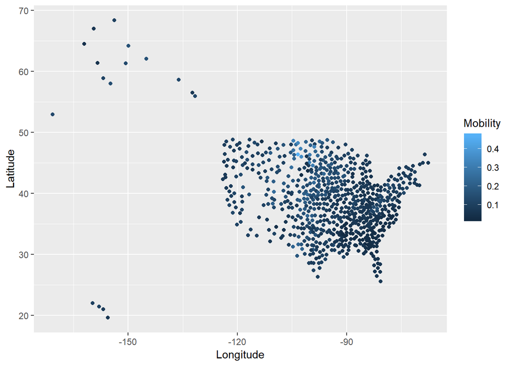

```r
final.dat.6x <- final.dat.5[,-1]
pred.y.6 <- predict(lm.fit.final.5, final.dat.6x)
final.dat.6 <- final.dat.5
final.dat.6 <- cbind(final.dat.6, pred.y.6)
# actual.y.6 <- final.dat.5[,1]
scatter.6a <- ggplot(data=final.dat.6, aes(x=Longitude, y=Latitude, col=Mobility)) + geom_point()
scatter.6a
```

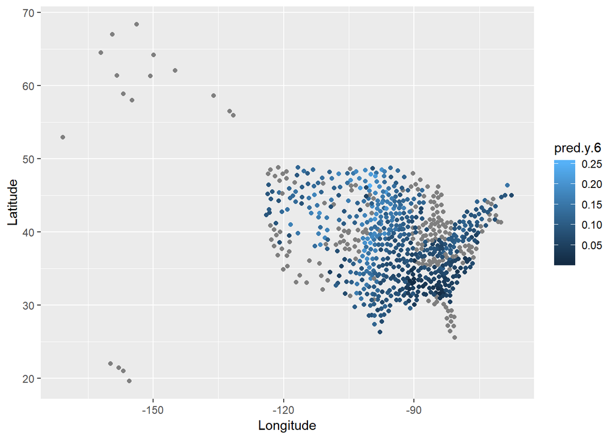

```r
scatter.6b <- ggplot(data=final.dat.6, aes(x=Longitude, y=Latitude, col=pred.y.6)) + geom_point()
scatter.6b
```

## 7. Just because I was there

Find Pittsburgh in the data set. For this question, assume that the model (you have fitted just before) is well-fitted.

#### a. What its actual mobility? What is its predicted mobility, according to the model?

*actual mobility는 0.09514869, predicted mobility는 0.09476822이다.*

```r
pit <- subset(raw, raw$Name=="Pittsburgh")
pit.actual.y <- pit[3]
pit.x <- subset(pit, select=-c(ID, Name, Progressivity, EITC, State, Seg_poverty, Seg_affluence, Gini_99, Share01))
pit.x[35]=TRUE
names(pit.x)[35]="HE"
pit.pred.y <- predict(lm.fit.final.5, pit.x)
pit.actual.y # 0.09514869
```

```
##       Mobility
## 229 0.09514869
```

```r
pit.pred.y # 0.09476822
```

```
##        229
## 0.09476822
```

#### b. Holding all else fixed, what is the predicted mobility if the violent crime rate is doubled? If it is halved?

*범죄율이 2배가 될 때 predicted mobility는 0.09133414이며, 범죄율이 절반이 될 때 predicted mobility는 0.09648526다.*

```r
# violent crime rate "doubled"
pit.x.7b <- pit.x
pit.x.7b[29] <- 0.002*2
pit.pred.7b1 <- predict(lm.fit.final.5, pit.x.7b)
# violent crime rate "halved"
pit.x.7b[29] <- 0.002/2
pit.pred.7b2 <- predict(lm.fit.final.5, pit.x.7b)
pit.pred.7b1 # 0.09133414
```

```
##        229
## 0.09133414
```

```r
pit.pred.7b2 # 0.09648526
```

```
##        229
## 0.09648526
```

#### c. Provide a 95% confidence interval for the expected mobility at Pittsburgh.

*피츠버그의 expected mobility의 95% 신뢰구간은 [0.08199654, 0.1075399]이다.*

```r
conf.interval <- predict(lm.fit.final.5, pit.x, interval="confidence")
conf.interval
```

```
##            fit        lwr       upr
## 229 0.09476822 0.08199654 0.1075399
```

#### d. Provide a 95% prediction interval for the expected mobility at Pittsburgh. Explain the difference.

*피츠버그의 expected mobility의 95% 예측구간은 [0.03839544, 0.151141]이다. 예측구간은 신뢰구간보다 넓다.*

```r
pred.interval <- predict(lm.fit.final.5, pit.x, interval="prediction")
pred.interval
```

```
##            fit        lwr      upr
## 229 0.09476822 0.03839544 0.151141
```

## 8. After making proper allowances

#### a. Make a map of the model’s residuals.

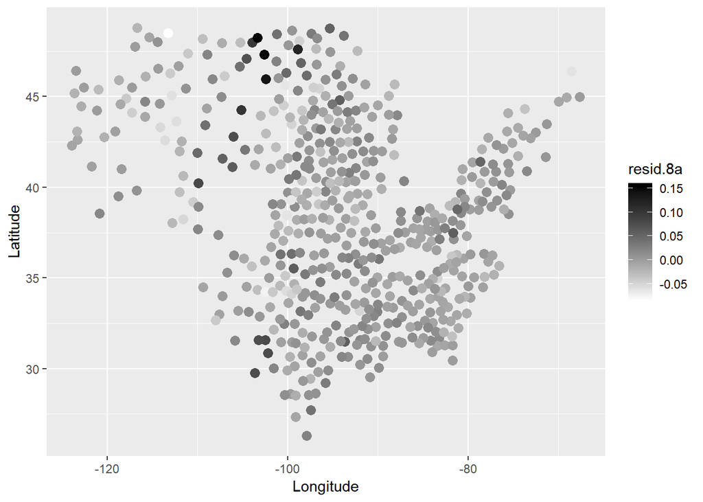

```r
final.dat.8 <- final.dat.5
num <-as.numeric(names(lm.fit.final.5$residuals))
final.dat.8 <- final.dat.8[num,]
final.dat.8$resid.8a <- lm.fit.final.5$residuals
scatter.8a <- ggplot(data=final.dat.8, aes(x=Longitude, y=Latitude, col=resid.8a)) + geom_point(size=3) + scale_color_gradient(low='white', high='black')
scatter.8a
```

#### b. What are the five communities with the largest positive residuals? The five with the most negative residuals? Provide the names of the communies. (Can you mark these on the map?)

```r
final.dat.8b <- raw[num,]
final.dat.8b$resid.8b <- lm.fit.final.5$residuals
posi.5 <- final.dat.8b %>% select(Name, resid.8b) %>% arrange(resid.8b) %>% head(5)
nega.5 <- final.dat.8b %>% select(Name, resid.8b) %>% arrange(desc(resid.8b)) %>% head(5)
posi.5.name <- posi.5[,1]
posi.5.name
```

```
## [1] Dillingham Deming     Denver     Milbank    Pratt
## 685 Levels: Aberdeen Abilene Ada Aiken Ainsworth Alamogordo ... Zanesville
```

```r
nega.5.name <- nega.5[,1]
nega.5.name
```

```
## [1] Glendive   Plentywood Baker      Steele     Colstrip
## 685 Levels: Aberdeen Abilene Ada Aiken Ainsworth Alamogordo ... Zanesville
```

## 9. Expectations and reality

#### a. Make a scatterplot of actual mobility against predicted mobility. Is the relationship linear? Should it be, if the model is right? Is the relationship flat? Should it be, if the model is right?

*산점도에서 actual mobility와 predicted mobility가 어느 정도 linear한 형태를 보이고 있다. model이 적합할수록, 각 데이터들은 y=x(파란색 선) 쪽으로 더 몰린다. 현재 산점도에서 꽤 선형 관계를 보이므로 좋은 모델이라고 할 수 있다.*

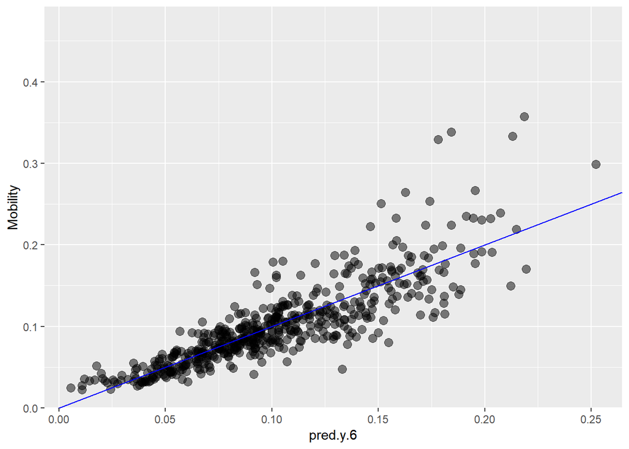

```r
final.dat.9 <- final.dat.5
scatter.9a <- ggplot(data=final.dat.9, aes(x=pred.y.6, y=Mobility)) + geom_point(size=3, alpha=0.5) + geom_abline(slope=1, intercept=0, col='blue')
scatter.9a
```

#### b. Make a scatterplot of the model’s residuals against predicted mobility. Is the relationship linear? Should it be, if the model is right? Is the relationship flat? Should it be, if the model is right?

*아래 산점도를 보면, 잔차가 y의 피팅값에 따라 변하지 않는다는 것을 알 수 있다. 그러나 잔차의 퍼짐 정도가 y의 피팅값이 증가하면서 같이 증가한다. 이는 등분산성이라는 linear regression의 가정을 위반한다. 아래 산점도에서 데이터가 골고루, 그리고 일정한 정도로(constant) 퍼져있어야 좋은 모델이라고 할 수 있다.*

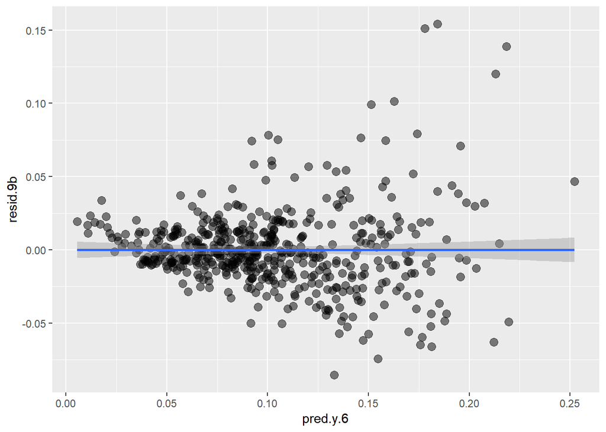

```r
final.dat.9b <- final.dat.6
# dim(final.dat.6)
final.dat.9b <- final.dat.9b[num,]
# dim(final.dat.9b)
final.dat.9b$resid.9b <- lm.fit.final.5$residuals
# names(final.dat.9b)
scatter.9b <- ggplot(data=final.dat.9b, aes(x=pred.y.6, y=resid.9b)) + geom_point(size=3, alpha=0.5) + geom_smooth(method='lm')
scatter.9b
```

## 10. Cross-validation, bootstrap and smoothing

For this question, focus on predicting mobility by the fraction of middle class in the community.

#### a. Fit a simple linear regression model to predict Mobility by Middle_class. Create a plot showing the data points, the fitted regression line, and 95% confidence and prediction intervals. For the intervals, assume that the error ϵ is i.i.d. N(0, sigma^2). (Is the assumption right?)

*오차가 정규성을 따르는지 확인하기 위해 잔차도를 확인했다. Normal Q-Q plot을 보아 완벽히는 아니지만 일부 정규성을 따르고 있는 것 같다.*

```r
lm.fit.10a <- lm(Mobility~Middle_class, data=final.dat.5)
summary(lm.fit.10a)
```

```
##
## Call:
## lm(formula = Mobility ~ Middle_class, data = final.dat.5)
##
## Residuals:
##       Min        1Q    Median        3Q       Max
## -0.077571 -0.026298 -0.009883  0.017227  0.215977
##
## Coefficients:
##              Estimate Std. Error t value Pr(>|t|)
## (Intercept)  -0.09698    0.01040  -9.328   <2e-16 ***
## Middle_class  0.35385    0.01871  18.908   <2e-16 ***
## ---
## Signif. codes:  0 '***' 0.001 '**' 0.01 '*' 0.05 '.' 0.1 ' ' 1
##
## Residual standard error: 0.03916 on 707 degrees of freedom
##   (20 observations deleted due to missingness)
## Multiple R-squared:  0.3358, Adjusted R-squared:  0.3349
## F-statistic: 357.5 on 1 and 707 DF,  p-value: < 2.2e-16
```

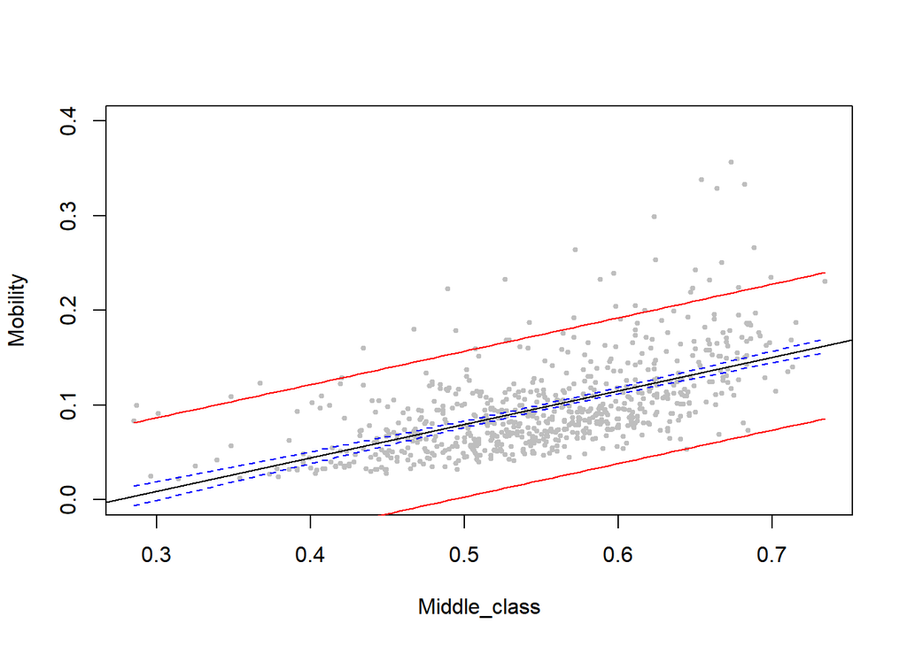

```r
# plot showing data points, the fitted line, and 95% conf and pred intervals
plot(Mobility~Middle_class, data=final.dat.5, pch=19, cex=0.5, col="grey", ylim=c(0,0.4))
abline(lm.fit.10a)
seq.10a <- seq(from=min(Middle_class, na.rm=TRUE), to=max(Middle_class, na.rm=TRUE), length.out=100)
CIs.10a <- predict(lm.fit.10a, newdata=data.frame(Middle_class=seq.10a), interval="confidence")
lines(seq.10a, CIs.10a[,"lwr"], lty="dashed", col="blue")
lines(seq.10a, CIs.10a[,"upr"], lty="dashed", col="blue")
PIs.10a <- predict(lm.fit.10a, newdata=data.frame(Middle_class=seq.10a), interval="prediction")
lines(seq.10a, PIs.10a[,"lwr"], col="red")
lines(seq.10a, PIs.10a[,"upr"], col="red")
```

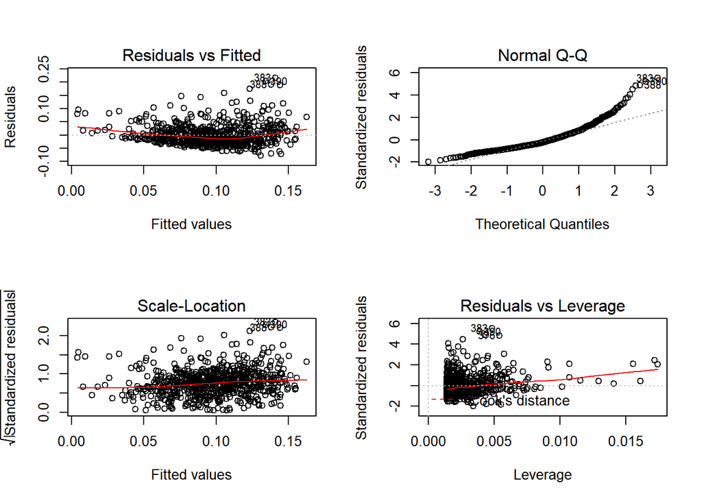

```r
# test the assumption
par(mfrow=c(2,2))
plot(lm.fit.10a)
```

#### b. Use a resampling method to obtain 95% confidence interval. Can you build a 95% prediction interval?

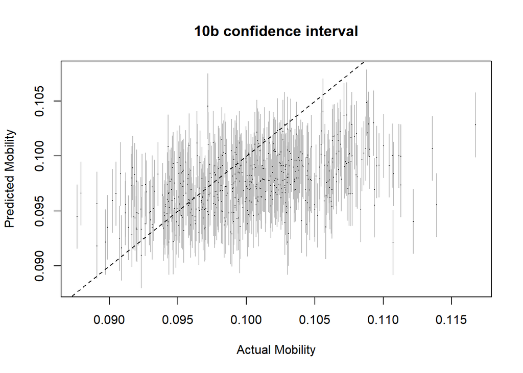

```r
boot <- list()
for(i in 1:500){
  boot[[i]] <- final.dat.5 %>% sample_n(size=100) %>% select(Mobility,Middle_class) %>%
    summarise(realy=mean(Mobility,na.rm=T), x=mean(Middle_class,na.rm=T))
}
boot_df <- bind_rows(boot)
realy <- boot_df[,1]
x <- boot_df[,2]
yhat <- predict(lm.fit.10a, newdata=data.frame(Middle_class=x))
# confidence interval
conf.lm<-as_tibble(predict(lm.fit.10a, newdata=data.frame(Middle_class=x), interval="confidence"))
plot(realy, yhat, type="n", pch=22, xlab="Actual Mobility",
     ylab="Predicted Mobility", main="10b confidence interval",
     ylim=c(min(conf.lm$lwr), max(conf.lm$upr)))
segments(realy, conf.lm$lwr, realy, conf.lm$upr, col="grey")
abline(a=0, b=1, lty="dashed")
points(realy, conf.lm$fit, pch=16, cex=0.1)
```

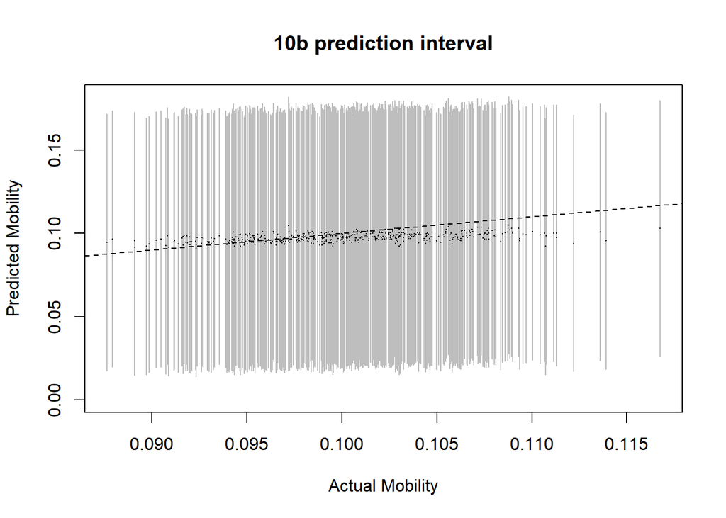

```r
# prediction interval
preds.lm<-as_tibble(predict(lm.fit.10a, newdata=data.frame(Middle_class=x), interval="predict"))
plot(realy, yhat, type="n", pch=22, xlab="Actual Mobility",
     ylab="Predicted Mobility", main="10b prediction interval",
     ylim=c(0, max(preds.lm$upr)))
segments(realy, preds.lm$lwr, realy, preds.lm$upr, col="grey")
abline(a=0, b=1, lty="dashed")
points(realy, preds.lm$fit, pch=16, cex=0.1)
```

#### c. Use a smoothing spline to do a nonparametric regression of Mobility on Middle_class. Use cross-validation to choose the degree of flexibility. Then use a resampling method to obtain 95% confidence interval. Create a plot showing the data points, the spline and the confidence interval.

```r
library(splines)
cbind.10c <- cbind(final.dat.5$Middle_class, final.dat.5$Mobility)
cbind.10c <- na.omit(cbind.10c)
x=cbind.10c[,1] # Middle_class
y=cbind.10c[,2] # Mobility
plot(x,y,cex=.7,col='darkgrey',xlab='Middle_class',ylab='Mobility')
title("Smoothing Spline")
fit.10c <- smooth.spline(x,y,cv=TRUE)
fit.10c$df
```

```
## [1] 5.056275
```

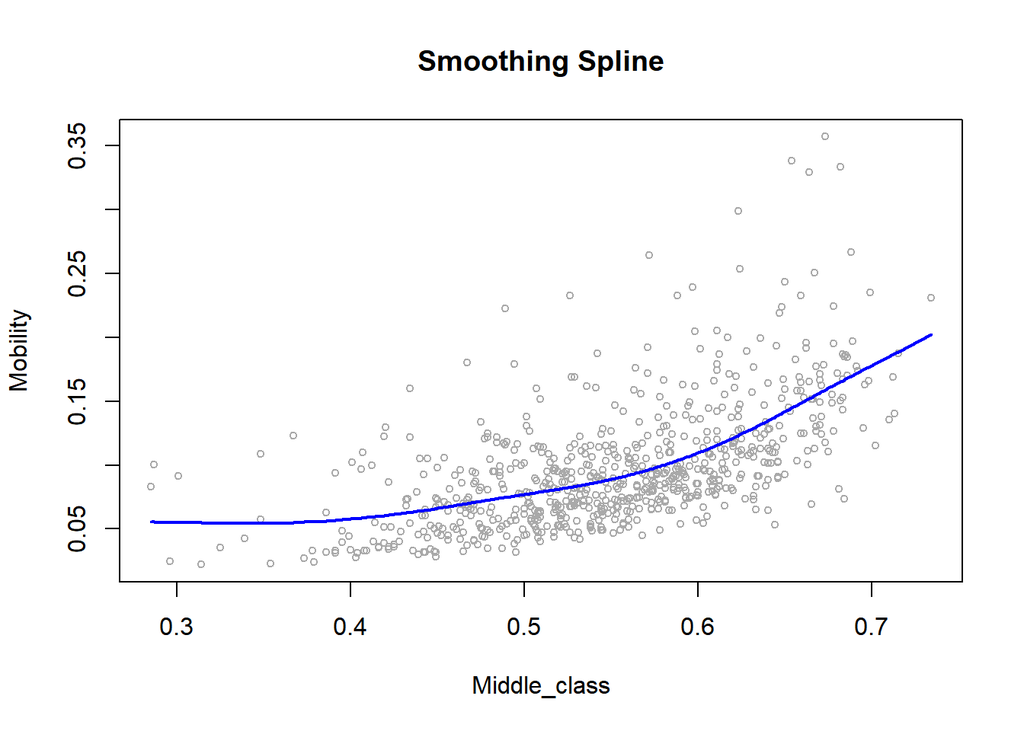

```r
lines(fit.10c,col='blue',lwd=2)
```

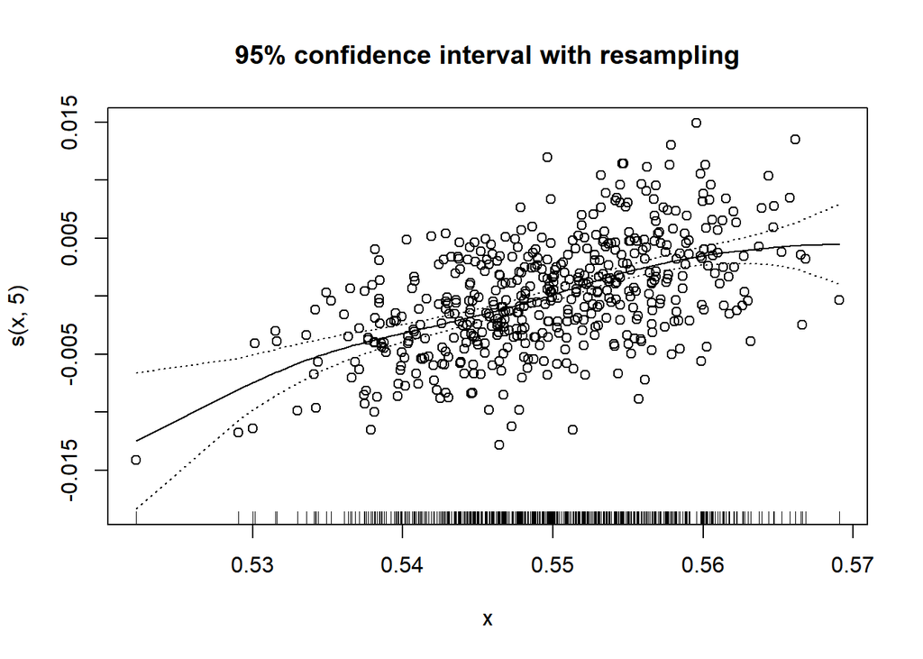

```r
# resampling
boot <- list()
for(i in 1:500){
  boot[[i]] <- final.dat.5 %>% sample_n(size=100) %>% select(Mobility,Middle_class) %>%
    summarise(realy=mean(Mobility,na.rm=T), x=mean(Middle_class,na.rm=T))
}
boot_df <- bind_rows(boot)
# gam and confidence interval
library(mgcv)
library(gam)
gam.10c <- gam(realy ~ s(x,5), data=boot_df)
preds.gam <- as_tibble(predict(gam.10c, interval="confidence"))
plot.Gam(gam.10c, scale=0, se=2, shade=TRUE, resid=TRUE, pages=1)
title("95% confidence interval with resampling")
```

#### d. Test whether smoothing is needed here.

```r
mod1=lm.fit.10a
mod2=gam.10c
var.test(mod1,mod2)
```

```
##
##  F test to compare two variances
##
## data:  mod1 and mod2
## F = 93.796, num df = 707, denom df = 494, p-value < 2.2e-16
## alternative hypothesis: true ratio of variances is not equal to 1
## 95 percent confidence interval:
##   79.61676 110.23689
## sample estimates:
## ratio of variances
##           93.79556
```

```r
var.test(mod1,mod2)$statistic
```

```
##        F
## 93.79556
```